# 3.5.2 - Advanced - Geospatial Analysis

advanced

geospatial

vector

R

S2

trade

distance

CRS

shapefile

This notebook explores geospatial analysis with vector data in R in more detail. We go over file types, choosing a CRS, as well as an application with real world data.

Published

24 June 2024

## Outline

### Prerequisites

- Geospatial Analysis 1
- Intermediate R skills
- Theoretical understanding of multiple regression
- Basic geometry

### Outcomes

After completing this notebook, you will be able to:

- Manipulate geospatial objects in R using the `sf` package.
- Perform geospatial operations on real world data.
- Use the `sf` package to read in shapefile data from online sources.
- Calculate distances using geospatial operations.
- Understand applications of geospatial analysis in the context of economic research.

### References

- [Geocomputation with R](https://r.geocompx.org/intro)
- Disdier, Anne-Célia, and Keith Head. “The Puzzling Persistence of the Distance Effect on Bilateral Trade.” The Review of Economics and Statistics, 2008.
- Pebesma, E., & Bivand, R. (2023). [Spatial Data Science: With Applications in R.](https://r-spatial.org/book/)
- Tinbergen, J. (1962) Shaping the World Economy: Suggestions for an International Economic Policy. The Twentieth Century Fund, New York.

## Introduction

In this notebook, we’ll continue our discussion of geospatial analysis with vector data. We’ll use trade data and shapefiles from Statistics Canada for our examples.

```r
# load packages
library(tidyverse)
library(ggplot2)
library(sandwich)
library(lmtest)
library(sf)
library(spData)
library(rmapshaper)
library(crsuggest)
```

## Part 1: Understanding Geospatial Data

> **Note**: geospatial files tend to be quite large and we use `for` loops in this notebook. It is possible that the code takes a while to run successfully.

### File types and sizes

In the previous notebook, we only worked with user-generated data and with datasets embedded in the package `spData`. It’s likely that for your applications, you’ll have to work with external geospatial files.

The most common of geospatial file type is the **ESRI Shapefile** for vector data. This file has the extension `.shp` and typically comes in a zipped folder with at least three associated files. The `sf` function to read shapefiles is `read_sf("filename.shp")`. There are many places to find shapefiles online. Some good places to look include [Geocommons](http://geocommons.com/), [Natural Earth](https://www.naturalearthdata.com/), and [Living Atlas](https://livingatlas.arcgis.com/en/browse/#d=2).

Other common file types for vector data include:

- GeoJSON (`.geojson`): extension of JSON file, mostly used for storing latitude and longitude coordinates.
- ESRI FileGDB (`.gdb`): stores objects created by ArcGIS (a popular software for geospatial analysis.
- GeoPackage (`.gpkg`): lightweight, platform-independent, and compact format.

It’s important to keep in mind that these files come in varying forms and sizes. It’s very common for shapefiles to be extremely detailed and highly-defined, which can exponentially increase the file size and runtime of your analysis. The function `ms_simplify()` from the package `rmapshaper` simplifies shapefiles by reducing the number of vertices of the spatial objects while maintaining the integrity of the shapes.

Let’s read a shapefile of Canadian provinces and plot them on a map with the attribute `province`.

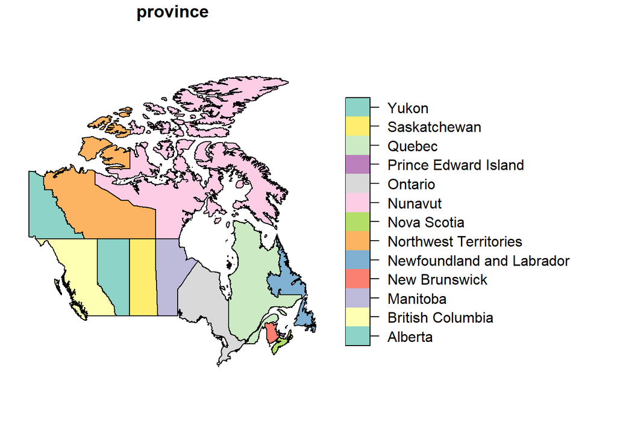

```r
shape <- read_sf("advanced_geospatial_datasets/advanced_geospatial_datasets.shp")

shape_plot <- plot(shape["province"])
```

Zoom in on the province boundaries and look at how detailed they are. We’re likely not going to need this level of detail for our analysis, so let’s simplify the file to avoid large runtimes. We’ll do so by using the function `ms_simplify()` to reduce the number of vertices to 1% of our current number.

```r
# run the code below to learn more about the function ms_simplify()
# ?ms_simplify
```

```r
# keep parameter indicates % of vertices to keep
canada_shape <- ms_simplify(shape, keep = 0.01, keep_shapes = TRUE)
```

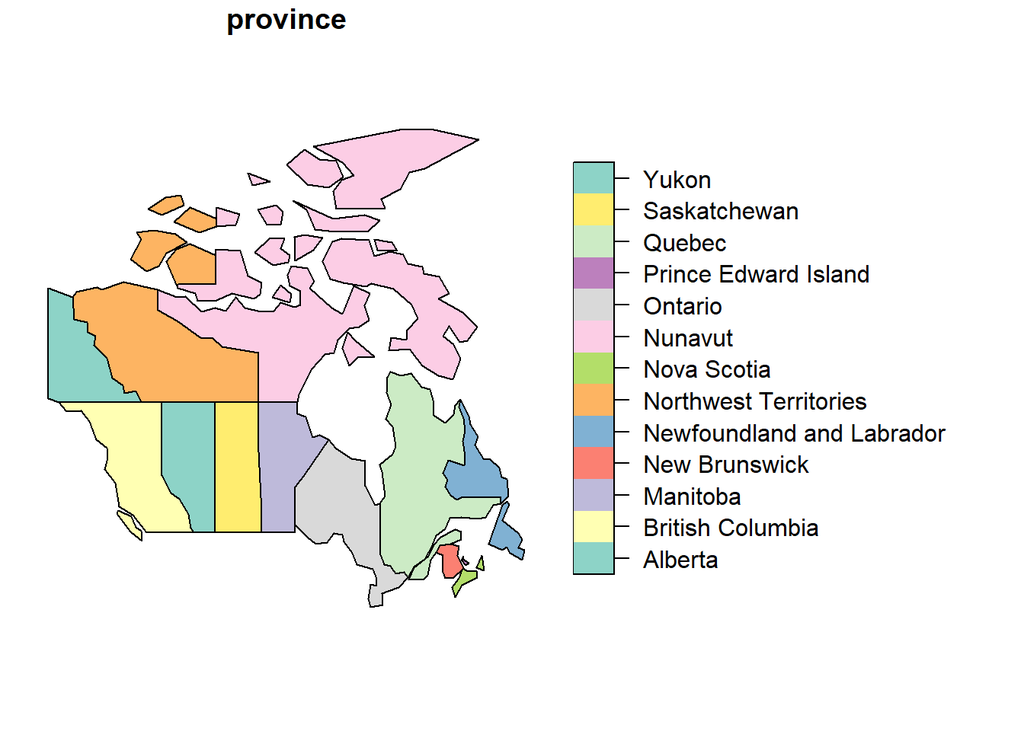

```r
plot(canada_shape["province"])
```

Note how now we have simplified the boundaries of the provinces. We can use the function `object.size()` to compare how much memory we’re saving by using our `canada_shape` instead of the large `shape` object.

```r
object.size(canada_shape)
```

```
29728 bytes
```

```r
object.size(shape)
```

```
874360 bytes
```

> **Note**: the object `shape` was already a simplified version of the high-definition shapefiles on the Statistics Canada website. Performing basic geospatial operations on those files could take multiple *minutes*!

### Choosing an appropriate CRS

As explained in our previous notebook, a CRS is the grid of reference for our geographic objects. These grids can be either **geographic**, coded in spherical longitude and latitude coordinates, or **projected**, coded in planar (x,y) coordinates.

The manner in which we identify the CRS is through a parameter of the form `AUTHORITY:CODE`. In the previous notebook, we used the identifier `EPSG:4326` to refer our geometric objects to the CRS WGS84, which is the most popular geographic CRS worldwide. When choosing a geographic CRS, you typically cannot go wrong with WGS84.

Choosing a projected CRS is often a tricky task - it depends on how you plan on using it. When projecting a geographic CRS, there will unavoidably be distortions to either the distances or the areas of the projected objects. The most common types of projections include:

- **Lambert azimuthal equal-area (LAEA) projections**: preserve equal-area at all locations but distorts shapes beyond thousands of kilometers.
- **Azimuthal equidistant (AEQD) projections**: maintain accurate straight-line distance between a point and the center point of the projection.
- **Lambert conformal conic (LCC) projections**: the cone is set to keep distance and area properties reasonable, which is useful for regions covering thousands of kilometers.
- **Stereographic (STERE) projections**: projections for polar regions, but with distortions on areas and distances thousands of kilometers from the center.

The package `crsuggest` has a function `suggest_crs()`, which takes a spatial object with a geographic CRS and returns a list of possible projected CRS’s that could be used for the given object.

We can use the function `st_crs()` to find out the CRS of our objects and `st_transform()` to change the CRS of the object.

```r
# run the cell to get information from the CRS
print(st_crs(canada_shape))
```

```
Coordinate Reference System:
  User input: NAD83
  wkt:
GEOGCRS["NAD83",
    DATUM["North American Datum 1983",
        ELLIPSOID["GRS 1980",6378137,298.257222101,
            LENGTHUNIT["metre",1]]],
    PRIMEM["Greenwich",0,
        ANGLEUNIT["degree",0.0174532925199433]],
    CS[ellipsoidal,2],
        AXIS["latitude",north,
            ORDER[1],
            ANGLEUNIT["degree",0.0174532925199433]],
        AXIS["longitude",east,
            ORDER[2],
            ANGLEUNIT["degree",0.0174532925199433]],
    ID["EPSG",4269]]
```

```r
st_crs(canada_shape)$IsGeographic
```

```
[1] TRUE
```

```r
st_crs(canada_shape)$units_gdal
```

```
[1] "degree"
```

From the output above we can see that `canada_shape` is in a geographic CRS called NAD83. This geographic CRS is customized to North America and has an `AUTHORITY:CODE` of `EPSG:4269`.

### Using S2 for operations in spherical coordinates

Now that we’ve looking in more detail at CRS’s, it’s time to introduce `S2`. `S2` is a dependency of the `sf` package and is used for geometric operations on spherical coordinates (i.e., when the CRS is in longitude and latitude coordinates). `S2` setups are especially important when calculating distances or setting buffers around objects.

This is better illustrated with an example. Let’s suppose we want to draw a buffer of distance 10 meters around the province of Alberta. Let’s perform this operation on our `canada_shape` dataset, first with `S2` turned on and then with `S2` turned off.

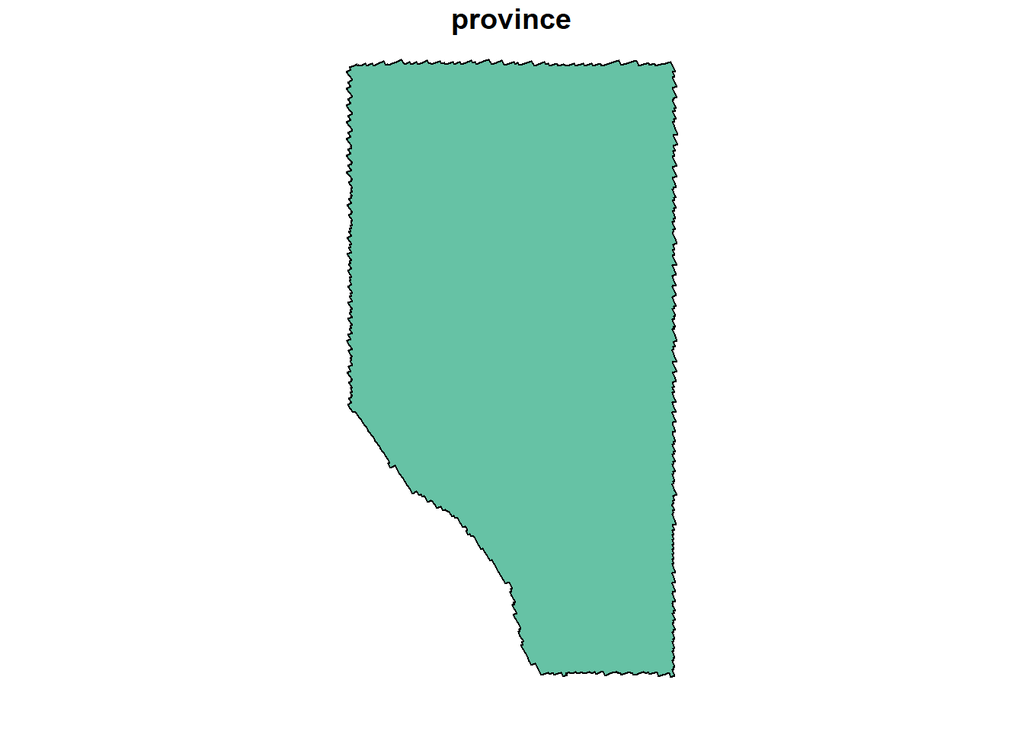

```r
# turn on `S2`
sf_use_s2(TRUE)

# define Alberta
alberta <- canada_shape[canada_shape$province == "Alberta", ]

plot(st_buffer(alberta, dist = 10))
```

```r
# turn off `S2`
sf_use_s2(FALSE)
```

```
Spherical geometry (s2) switched off
```

[output not shown]

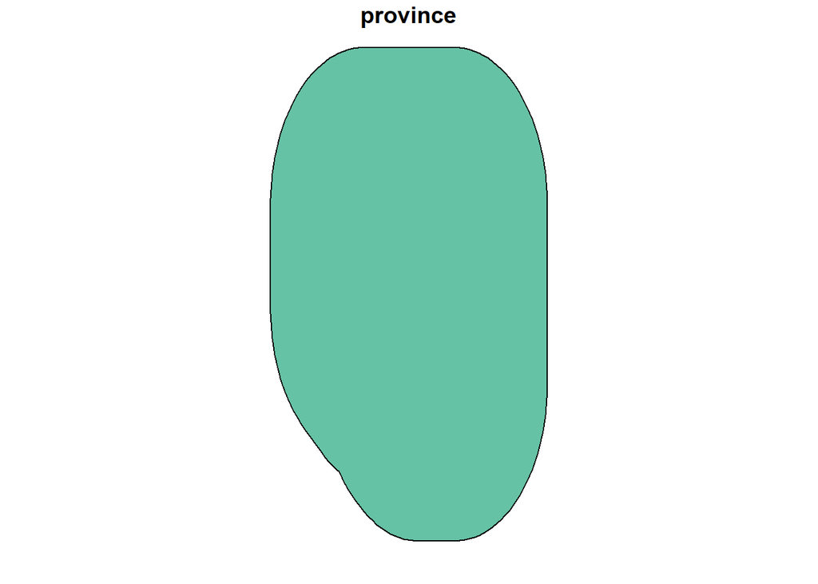

```r
# define Alberta
alberta <- canada_shape[canada_shape$province == "Alberta", ]

plot(st_buffer(alberta, dist = 10))
```

Notice the difference? That happens because when `S2` is turned off, the operation is performed in *degrees* and not in meters. Since the length of degrees change according to the longitude and latitude of the object, the buffers won’t be equidistant to the borders.

Now, let’s try to calculate the distance between Alberta and Ontario with `S2` turned on and off.

```r
# turn on `S2`
sf_use_s2(TRUE)
```

```
Spherical geometry (s2) switched on
```

```r
# calculate distance
alberta <- canada_shape[canada_shape$province == "Alberta", ]
ontario <- canada_shape[canada_shape$province == "Ontario", ]

st_distance(alberta, ontario)
```

```
Units: [m]
         [,1]
[1,] 990429.2
```

```r
# turn off `S2`
sf_use_s2(FALSE)

# calculate distance
alberta <- canada_shape[canada_shape$province == "Alberta", ]
ontario <- canada_shape[canada_shape$province == "Ontario", ]

st_distance(alberta, ontario)
```

[output not shown]

Notice that when `S2` is turned off, we get a very different number. The main takeaway is that we should use `S2` when applying geospatial operations to objects with geographic coordinates.

The diagram below shows how R uses `S2` for geometric operations.

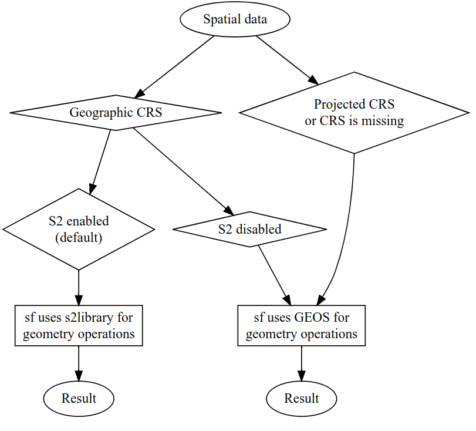

Lovelace, Robin and Nowosad, Jakub and Muenchow, Jannes, (2019). Geocomputation with R.

Let’t turn `S2` back on for the remainder of our analysis.

```r
sf_use_s2(TRUE)
```

## Part 2: Gravity Equation of Trade

### Theory

In the 1660’s, Isaac Newton formalized the law of gravity: particles attract each other with a force that is proportional to the product of their masses and inversely proportional to the square of their distance. In 1962, Dutch economist Jan Tinberg adapted the law of gravity to international trade. Tinberg (1962) proposed that the aggregate trade flows between any two countries is “proportional to the gross national products of those countries and inversely proportional to the distance between them.” Mathematically, that means

$$Trade = G \frac{Mass_{1}^\alpha Mass_{2}^\beta}{Distance^\theta}$$

Since then, there have been numerous attempts to estimate the effects of both economic mass and distance on trade flows empirically. By taking logs of both sides of the equation, we can show that the gravity equation translates to

$$log(Trade) = log(G) + \alpha log(Mass_{1}) + \beta log(Mass_{2}) - \theta log(Distance)$$

In this section, we’ll try to estimate the effect of distance on trade flows using data from Canadian provinces and US states.

### Empirical Methods

Empirically, we can estimate the effect of distance on trade with an adaptation of the model above. For a Canadian province $i$ and a US state $j$:

$$log(T_{ij}) = \beta_{0} + \beta_{1} log(Y_{j}) - \beta_{2} log(X_{ij}) + \sum_{i=2}^{13} \gamma_{i} D_{i} + \epsilon$$

where

- $T_{ij}$ is total merchandise volume between province $i$ and state $j$
- $Y_{j}$ is the GDP of state $j$
- $X_{ij}$ is the distance between province $i$ and state $j$
- $D_{i}$ is a dummy for province $i$

This specification is similar to the traditional gravity equation; by controlling for provinces with dummy variables, we implicitly control for the economic masses of those provinces.

The effect of interest is the coefficient on distance, $\beta_{2}$, which can be interpreted as trade elasticity: the percentage change in total merchandise volume from a 1% change in distance.

### Data Cleaning and Wrangling

We have three datasets for this analysis: `canada_shape`, `us_states`, and `trade_data`. The first 2 datasets contain the shapefiles of Canadian provinces and US states, and the last file contains trade data from Statistics Canada. Let’s load our datasets.

```r
# load trade data
trade_data <- read_csv("advanced_geospatial_datasets/trade_data.csv")
head(trade_data)
```

```
# A tibble: 6 × 5
   ...1 province state      tmerch_value_usd      gdp
  <dbl> <chr>    <chr>                 <dbl>    <dbl>
1     1 Alberta  Alabama           877384086  234526.
2     2 Alberta  Alaska            345988655   54470.
3     3 Alberta  Arizona           423062944  375545
4     4 Alberta  Arkansas          121043779  132637.
5     5 Alberta  California       4450662689 3062159.
6     6 Alberta  Colorado         3916792877  397702.
```

```r
# view canada_shape (we've loaded it in the previous section)
head(canada_shape)
```

```
Simple feature collection with 6 features and 1 field
Geometry type: GEOMETRY
Dimension:     XY
Bounding box:  xmin: -141.0114 ymin: 44.99114 xmax: -57.10776 ymax: 83.10995
Geodetic CRS:  NAD83
# A tibble: 6 × 2
  province                                                              geometry
  <chr>                                                           <GEOMETRY [°]>
1 British Columbia     MULTIPOLYGON (((-128.0536 50.87683, -128.3035 50.60872, …
2 Quebec               MULTIPOLYGON (((-66.32593 48.06076, -64.34198 48.41909, …
3 Nunavut              MULTIPOLYGON (((-85.49845 65.92457, -86.39498 64.58634, …
4 Prince Edward Island POLYGON ((-63.98864 47.03119, -64.40965 46.70758, -63.58…
5 Saskatchewan         POLYGON ((-102 60, -110 60, -110 56.92908, -110.0057 54.…
6 Yukon                POLYGON ((-136.4686 68.86875, -141.0114 69.64746, -141.0…
```

```r
# view us_states (comes with spData package)
head(us_states)
```

```
Simple feature collection with 6 features and 6 fields
Geometry type: MULTIPOLYGON
Dimension:     XY
Bounding box:  xmin: -114.8136 ymin: 24.55868 xmax: -71.78699 ymax: 42.04964
Geodetic CRS:  NAD83
  GEOID        NAME   REGION             AREA total_pop_10 total_pop_15
1    01     Alabama    South 133709.27 [km^2]      4712651      4830620
2    04     Arizona     West 295281.25 [km^2]      6246816      6641928
3    08    Colorado     West 269573.06 [km^2]      4887061      5278906
4    09 Connecticut Norteast  12976.59 [km^2]      3545837      3593222
5    12     Florida    South 151052.01 [km^2]     18511620     19645772
6    13     Georgia    South 152725.21 [km^2]      9468815     10006693
                        geometry
1 MULTIPOLYGON (((-88.20006 3...
2 MULTIPOLYGON (((-114.7196 3...
3 MULTIPOLYGON (((-109.0501 4...
4 MULTIPOLYGON (((-73.48731 4...
5 MULTIPOLYGON (((-81.81169 2...
6 MULTIPOLYGON (((-85.60516 3...
```

By looking at the “trade_data” dataset, we see that:

- We already have data on total merchandise volume (`tmerch_value_usd`) between provinces and states
- We already have data on the GDP of US states (`gdp`)
- We can easily create dummies for each Canadian province with the column `province`

Therefore, the only variable missing for our specification is the distance between each province-state pair. We can use our shapefiles to calculate the distance between provinces and states with the function `st_distance` from the `sf` package.

We want a dataset with the following structure:

| Province | State | Total Merchandise Volume (USD) | State GDP (USD) | Distance (Km) |
| --- | --- | --- | --- | --- |
| Alberta | Alabama | USD | USD | Km |
| Alberta | Arkansas | USD | USD | Km |
| Alberta | Arizona | USD | USD | Km |

The easiest way to do this is by creating an `sf` object with the distance values, and then merging it with `trade_data` using the fields `province` and `state`.

Before we do that, let’s take a look at the CRS of our shapefiles.

```r
# look at CRS details
st_crs(canada_shape)$WktPretty #WktPretty makes it easier to see the CRS parameters
```

```
[1] "GEOGCS[\"NAD83\",\n    DATUM[\"North_American_Datum_1983\",\n        SPHEROID[\"GRS 1980\",6378137,298.257222101]],\n    PRIMEM[\"Greenwich\",0],\n    UNIT[\"degree\",0.0174532925199433,\n        AUTHORITY[\"EPSG\",\"9122\"]],\n    AXIS[\"Latitude\",NORTH],\n    AXIS[\"Longitude\",EAST],\n    A…
```

```r
st_crs(us_states)$WktPretty
```

```
[1] "GEOGCS[\"NAD83\",\n    DATUM[\"North_American_Datum_1983\",\n        SPHEROID[\"GRS 1980\",6378137,298.257222101,\n            AUTHORITY[\"EPSG\",\"7019\"]],\n        TOWGS84[0,0,0,0,0,0,0],\n        AUTHORITY[\"EPSG\",\"6269\"]],\n    PRIMEM[\"Greenwich\",0,\n        AUTHORITY[\"EPSG\",\"8901\…
```

Our objects reference the same CRS - the geographic NAD83 CRS. We could just go ahead and calculate the distance between our objects (as long as our `S2` is turned on!); however, for learning purposes, let’s take a look at the projected suggestions from the function `suggest_crs()`.

```r
# find list of suggested CRS
suggest_crs(canada_shape, type = "projected", units = "m") #note that the units must be in metres instead of km
```

```
# A tibble: 10 × 6
   crs_code crs_name                        crs_type crs_gcs crs_units crs_proj4
   <chr>    <chr>                           <chr>      <dbl> <chr>     <chr>
 1 5931     WGS 84 / EPSG Arctic Regional … project…    4326 m         +proj=lc…
 2 3979     NAD83(CSRS) / Canada Atlas Lam… project…    4617 m         +proj=lc…
 3 3978     NAD83 / Canada Atlas Lambert    project…    4269 m         +proj=lc…
 4 3348     NAD83(CSRS) / Statistics Canad… project…    4617 m         +proj=lc…
 5 3347     NAD83 / Statistics Canada Lamb… project…    4269 m         +proj=lc…
 6 5926     WGS 84 / EPSG Arctic Regional … project…    4326 m         +proj=lc…
 7 5921     WGS 84 / EPSG Arctic Regional … project…    4326 m         +proj=lc…
 8 6350     NAD83(2011) / Conus Albers      project…    6318 m         +proj=ae…
 9 5072     NAD83(NSRS2007) / Conus Albers  project…    4759 m         +proj=ae…
10 5071     NAD83(HARN) / Conus Albers      project…    4152 m         +proj=ae…
```

```r
suggest_crs(us_states, type = "projected", units = "m")
```

```
# A tibble: 10 × 6
   crs_code crs_name                        crs_type crs_gcs crs_units crs_proj4
   <chr>    <chr>                           <chr>      <dbl> <chr>     <chr>
 1 6350     NAD83(2011) / Conus Albers      project…    6318 m         +proj=ae…
 2 5072     NAD83(NSRS2007) / Conus Albers  project…    4759 m         +proj=ae…
 3 5071     NAD83(HARN) / Conus Albers      project…    4152 m         +proj=ae…
 4 5070     NAD83 / Conus Albers            project…    4269 m         +proj=ae…
 5 5069     NAD27 / Conus Albers            project…    4267 m         +proj=ae…
 6 6500     NAD83(2011) / Minnesota Central project…    6318 m         +proj=lc…
 7 3594     NAD83(NSRS2007) / Minnesota Ce… project…    4759 m         +proj=lc…
 8 2811     NAD83(HARN) / Minnesota Central project…    4152 m         +proj=lc…
 9 26992    NAD83 / Minnesota Central       project…    4269 m         +proj=lc…
10 6504     NAD83(2011) / Minnesota South   project…    6318 m         +proj=lc…
```

```r
# selecting the columns we'll need from `us_states`
us_shape <- us_states %>%
            select(state = NAME, geometry)
```

Let’s plot our shape files on a map and then turn to merging our datasets.

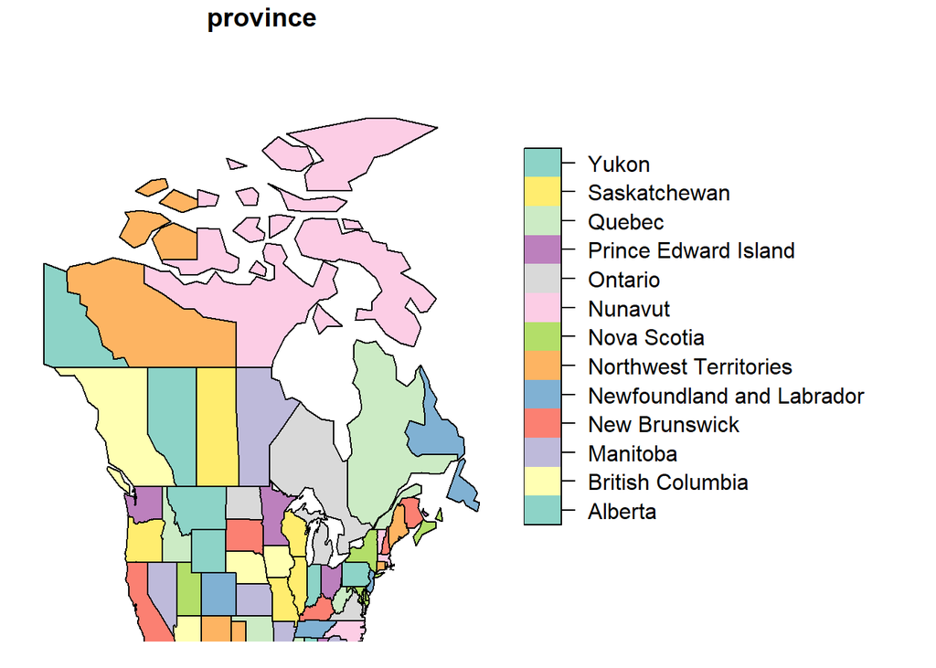

```r
plot(canada_shape["province"], reset = FALSE)
plot(us_shape["state"], add = TRUE)
```

### Creating our `sf` Object for the Distances

Since our shapefiles are in two separate files, the approach we’re going to take is:

1. Create a vector with the labels `province` and `state`
2. Create a vector with the `distance` between each province-state pair
3. Merge those vectors together in a dataframe
4. Inner join the dataframe with the `trade_data` file

By approaching the data wrangling step-by-step, we can see exactly what is going on and can check our work each step of the way. This is often preferred when working with multiple datasets and merging through variables that are not factors (we have to merge datasets through province-state names!).

Let’s start with Step (1). We’ll create nested `for` loops, indexing provinces with `i` and states with `j`. Follow the comments of the code.

```r
province_num <- nrow(canada_shape)    # each entry of `canada_shape` is a province
states_num <- nrow(us_shape)    # each entry of `us_shape` is a state

prov_state_vec <- c()    # create a placeholder vector that will contain the `province - state` pairs
for (i in 1:province_num){    # start the loop with a province i, from a set of 1 to `province_num` provinces
    prov_i <- canada_shape$province[i]    # select province name indexed by i

    for (j in 1:states_num){    # for the selected province i, loop through the states, indexed by j
        state_j <- us_shape$state[j]    # select state name indexed by j
        prov_state_pair <- paste(prov_i, "-", state_j)    # paste prov i and state j as a string separated by a dash
        prov_state_vec <- append(prov_state_vec, prov_state_pair)    # append the `province-state` pair "i - j" to the placeholder vector
    }    # close state loop for state j and repeat process for state j + 1
}    # close province loop for province i and repeat process for province i + 1
head(prov_state_vec)
```

```
[1] "British Columbia - Alabama"     "British Columbia - Arizona"
[3] "British Columbia - Colorado"    "British Columbia - Connecticut"
[5] "British Columbia - Florida"     "British Columbia - Georgia"
```

Let’s check if our loop worked as intended. We have 13 provinces and 49 states, so we should have a total of $(13)(49) = 637$ province-state pairs.

> **Note**: you can check the number of provinces and states by running `nrow(canada_shape)` and `nrow(us_shape)`. We’re missing Hawaii and Alaska, and we’re counting the District of Columbia as a state.

```r
length(prov_state_vec)
```

```
[1] 637
```

> **Note**: this operation might take a while to run.

```r
province_num <- nrow(canada_shape)
states_num <- nrow(us_shape)

distance_vec <- c()
for (i in 1:province_num){
    geo_prov_i <- st_make_valid(canada_shape$geometry[i])    # retrieve province geometry and adjust polygons with multiple vertices

    for (j in 1:states_num) {
        geo_state_j <- st_make_valid(us_shape$geometry[j])    # retrieve state geometry and adjust polygons with multiple vertices
        distance <- as.double(st_distance(geo_prov_i, geo_state_j))    # calculate distance in meters
        distance_vec <- append(distance_vec, distance)
   }

}
head(distance_vec)
```

```
[1] 2622119.6 1334291.8  972563.8 3213385.0 2987075.0 2795721.8
```

Do you see the distances? For Step 3, let’s merge both vectors into a dataframe with `cbind`, and then separate the state and province match into 2 columns with `separate_wider_delim`.

```r
# merging distance files
distance_data <- as.data.frame(cbind(prov_state_vec, distance_vec)) %>%
                separate_wider_delim(prov_state_vec, names = c("province", "state"), delim = "-") %>%
                mutate(province = trimws(province), state = trimws(state), distance_m = as.numeric(distance_vec)) %>%    # trimming white-space
                select(-distance_vec)
head(distance_data)
```

```
# A tibble: 6 × 3
  province         state       distance_m
  <chr>            <chr>            <dbl>
1 British Columbia Alabama       2622120.
2 British Columbia Arizona       1334292.
3 British Columbia Colorado       972564.
4 British Columbia Connecticut   3213385.
5 British Columbia Florida       2987075.
6 British Columbia Georgia       2795722.
```

> **Note**: The reason we are able to use `cbind()` to merge the two dataframes without a unique identifier is because they are ordered exactly the same. Our two `for` loops create pairs in an identical manner, so the distance pairs will ordered the same as our province-state pairs. We would not be able to do this is if they were ordered differently!

As a sanity check, let’s calculate the number of pairs per province (each province should be paired with exactly 49 states) and confirm that provinces and states that border each other have distance equal zero.

```r
# group observations by `province` and calculate number of observations per province
number_pairs <- distance_data %>%
                group_by(province) %>%
                summarize(n = n())
number_pairs
```

```
# A tibble: 13 × 2
   province                      n
   <chr>                     <int>
 1 Alberta                      49
 2 British Columbia             49
 3 Manitoba                     49
 4 New Brunswick                49
 5 Newfoundland and Labrador    49
 6 Northwest Territories        49
 7 Nova Scotia                  49
 8 Nunavut                      49
 9 Ontario                      49
10 Prince Edward Island         49
11 Quebec                       49
12 Saskatchewan                 49
13 Yukon                        49
```

```r
# find border countries for distance in meters equal zero
border_pairs <- distance_data %>%
                filter(distance_m == 0)
print(border_pairs)
```

```
# A tibble: 8 × 3
  province         state         distance_m
  <chr>            <chr>              <dbl>
1 British Columbia Washington             0
2 Quebec           New York               0
3 Quebec           Vermont                0
4 Quebec           Maine                  0
5 Quebec           New Hampshire          0
6 Ontario          Minnesota              0
7 Ontario          New York               0
8 New Brunswick    Maine                  0
```

We only get 8 borders! That’s clearly not accurate.

What’s going on here is that whenever dealing with geospatial data, we’re always working with approximations of actual physical objects, so the data is bound to have minor errors - it’s very hard to code physical elements into just a few data points! Let’s add a tolerance of 100m to our definition of border.

> **Think Deeper**: how would you choose a reasonable tolerance for distance calculations?

```r
# find border countries for distance in meters equal zero
border_pairs <- distance_data %>%
                filter(distance_m < 100)
print(border_pairs)
```

```
# A tibble: 14 × 3
   province         state         distance_m
   <chr>            <chr>              <dbl>
 1 British Columbia Montana            20.6
 2 British Columbia Washington          0
 3 Quebec           New York            0
 4 Quebec           Vermont             0
 5 Quebec           Maine               0
 6 Quebec           New Hampshire       0
 7 Saskatchewan     Montana             7.97
 8 Saskatchewan     North Dakota       26.8
 9 Manitoba         Minnesota          73.0
10 Manitoba         North Dakota       26.8
11 Ontario          Minnesota           0
12 Ontario          New York            0
13 New Brunswick    Maine               0
14 Alberta          Montana             7.97
```

Much better, but we’re still missing 2 border pairs - Ontario and Michigan and British Columbia and Idaho. Let’s check their distances.

```r
missing_pairs <- distance_data %>%
                        filter(province %in% c("Ontario", "British Columbia"), state %in% c("Michigan", "Idaho"))
missing_pairs
```

```
# A tibble: 4 × 3
  province         state    distance_m
  <chr>            <chr>         <dbl>
1 British Columbia Idaho         3223.
2 British Columbia Michigan   1780276.
3 Ontario          Idaho      1330823.
4 Ontario          Michigan     10720.
```

Our data says that those border pairs are a few kilometers apart. What happened here is that when we calculated the distance, we adjusted the borders of the `multipolygon` shapes to avoid duplicate edges with the function `st_make_valid()`. This affected the Ontario and British Columbia borders with some US states. Since this affects the distances in a similar manner, it likely doesn’t pose major issues to our analysis. Let’s proceed to Step 4.

```r
# merge our `trade_data` with our `distance_data`
geo_data <- merge(trade_data, distance_data, by = c("province", "state"))%>%    # inner-join based on `province` and `state`
                mutate(dist_km = if_else(distance_m < 1000, 1, distance_m/1000),   # setting borders to 1 km distance to avoid log zeros
                       tmerch_mi = tmerch_value_usd/1000000,
                       state_gdp_mi = gdp)%>%
                select(province, state, dist_km, state_gdp_mi, tmerch_mi)%>%
                filter(!is.na(dist_km), !is.na(tmerch_mi), !is.na(state_gdp_mi))    # remove pairs with no trade flows
head(geo_data)
```

[output not shown]

Great! We finally compiled our data. Let’s look at how many pairs we have.

```r
# group observations by `province` and calculate number of observations per province
number_pairs_final <- geo_data %>%
                group_by(province) %>%
                summarize(n = n())
number_pairs_final
```

```
# A tibble: 13 × 2
   province                      n
   <chr>                     <int>
 1 Alberta                      49
 2 British Columbia             49
 3 Manitoba                     49
 4 New Brunswick                49
 5 Newfoundland and Labrador    48
 6 Northwest Territories        15
 7 Nova Scotia                  49
 8 Nunavut                       8
 9 Ontario                      49
10 Prince Edward Island         49
11 Quebec                       49
12 Saskatchewan                 49
13 Yukon                        36
```

It looks like there are a few province-country pairs with few trade flows. Let’s filter out provinces that don’t trade with all 49 US states.

```r
# filter data
model_data <- geo_data %>%
              group_by(province) %>%
              mutate(n = n()) %>%
              filter(n == 49) %>%
              select(-n)%>%
              ungroup()

nrow(model_data)
```

```
[1] 441
```

> **Think Deeper**: how would *not* removing those pairs affect the results of our regression? Instead of filtering our dataset, what else could we do to solve this issue?

### Exploring our Data

Now that we have our data, let’s plot a scatterplot to visualize our relationships. Let’s filter the data to only British Columbia pairs and plot the `distance` between the BC-state pairs against the `tmerch_mi` trade between BC-state pairs. Let’s also set the size of each data point to be the GDP of the US states.

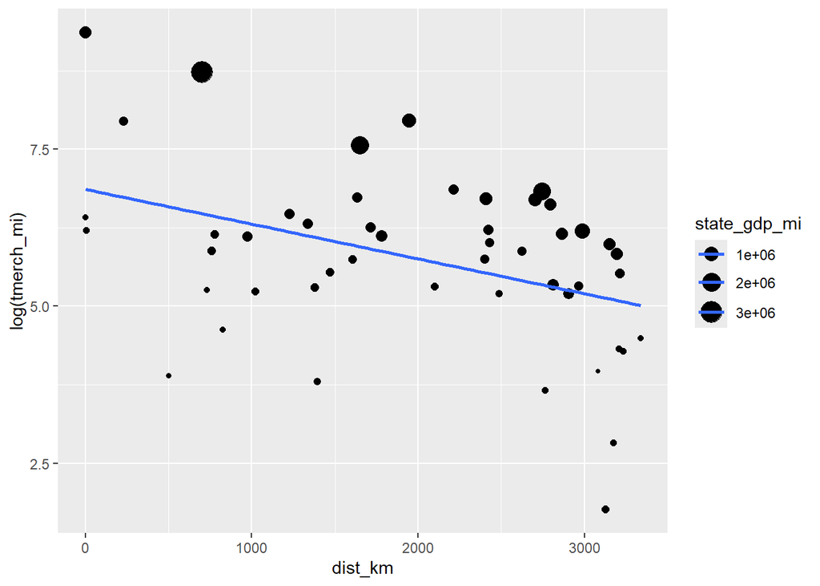

```r
# filter data to BC-state pairs
BC_data <- model_data %>%
            filter(province == "British Columbia")

# plot dist_km against log(tmerch_mi) and add a line of best fit
ggplot(BC_data, aes(x = dist_km, y = log(tmerch_mi), size = state_gdp_mi)) +
            geom_point() +
            geom_smooth(method = lm, se = FALSE, linewidth = 1)
```

The line of best fit shows a negative relationship between distance and trade. Also note that the largest data points are above the line: all else equal, higher GDP is associated with higher trade levels.

### Running our Model

Now, let’s run our model using `lm()`.

```r
model1 <- lm(log(tmerch_mi) ~ log(dist_km) + province + log(state_gdp_mi), data = model_data)
coeftest(model1, vcov = vcovHC)
```

```
t test of coefficients:

                              Estimate Std. Error  t value  Pr(>|t|)
(Intercept)                  -3.375973   0.719585  -4.6916 3.649e-06 ***
log(dist_km)                 -0.496410   0.054130  -9.1707 < 2.2e-16 ***
provinceBritish Columbia     -0.710966   0.232052  -3.0638 0.0023227 **
provinceManitoba             -1.100678   0.252325  -4.3621 1.614e-05 ***
provinceNew Brunswick        -2.189081   0.281099  -7.7876 5.159e-14 ***
provinceNova Scotia          -3.105333   0.259423 -11.9701 < 2.2e-16 ***
provinceOntario               0.898792   0.245672   3.6585 0.0002852 ***
provincePrince Edward Island -4.471766   0.296617 -15.0759 < 2.2e-16 ***
provinceQuebec                0.067123   0.241448   0.2780 0.7811433
provinceSaskatchewan         -1.549416   0.299594  -5.1717 3.563e-07 ***
log(state_gdp_mi)             1.074339   0.057314  18.7448 < 2.2e-16 ***
---
Signif. codes:  0 '***' 0.001 '**' 0.01 '*' 0.05 '.' 0.1 ' ' 1
```

Our regression indicates that a 1% increase in distance is associated with a 0.5% decrease in trade flows. Our parameter is statistically significant at the 1% level. As expected, the state GDP control is also positive and significant.

### Discussion

Our geospatial analysis suggests that the relationships drawn by Tilberg hold for Canada and the US: distance is inversely proportional to trade flows. The negative relationship between distance and trade flows has been consistently found in the literature, but the magnitude of the effects vary with time and geography.

In a comprehensive study about the effects of distance on bilateral trade, Disdier and Head (2008) compiled 1467 different distance effect estimates from 103 papers. They found that the mean distance effect is 0.9 - that is, a 10% increase in distance lowers bilateral trade by about 9%. Furthermore, 90% of the estimates compiled fall within the range of 0.28 to 1.55, dependent on the time period and geography of the study. It seems that our results are in line with what the researchers found, which adds to the credibility of our estimates from a simple model.

This example concludes our modules on geospatial analysis. If you’re curious to learn more about the topics explored in these modules, refer to:

- [Geocomputation with R](https://r.geocompx.org/intro): for more context around Geospatial analysis in general
- [This blog post](https://cran.r-project.org/web/packages/gravity/vignettes/crash-course-on-gravity-models.html): for more ways to model gravity
- [This user guide](https://www.unescap.org/sites/default/files/Gravity-model-in-R_1.pdf): for more context aroung the Gravity Equation of International Trade in R